# USAID SCMS Health Logistics

Data Scientist Technical Report

Data Scientist Track Submission by Murera Gisa

March 11, 2026

## Executive Summary

This report fulfils the **Data Scientist track** of the SFH Rwanda technical challenge. It covers EDA, data quality and inconsistency checks, data transformation, hypothesis testins and some visual representations from the data.

This report presents an exploratory data analysis (EDA) of the `USAID SCMS Delivery History Dataset`, focusing on **data quality issues** and testing a key **business hypothesis** about shipping mode costs. The analysis identifies three critical data quality issues that must be addressed before any modeling/dashboarding or reporting, and provides statistical evidence for air freight being significantly more expensive than truck transport for heavy loads.

Finaly this reports provides the overall reproducible functions to automatically validate the data since it is vital and important for any data-related project.

## 1. Data Loading and Initial Inspection

```r
# Load the raw dataset
raw <- read_csv(here::here("data/raw/SCMS_Delivery_History_Dataset.csv"),
                locale = locale(encoding = "latin1"),  # handles Côte d'Ivoire accent
                show_col_types = FALSE) %>% janitor::clean_names()

# Display basic dataset information
cat(sprintf("  Rows    : %d\n",    nrow(raw)))
```

```
##   Rows    : 10324
```

```r
cat(sprintf("  Columns : %d\n",    ncol(raw)))
```

```
##   Columns : 33
```

```r
cat(sprintf("  Period  : %s  to  %s\n\n",
            min(raw$scheduled_delivery_date, na.rm = TRUE),
            max(raw$scheduled_delivery_date, na.rm = TRUE)))
```

```
##   Period  : 1-Apr-08  to  9-Sep-15
```

## 2.Data Quality Issues

This section presents the data quality issues and present them in interactive way.

### Issue no. 1: Non numeric Freight Cost Values

*State of the Problem:* The freight_cost_usd column contains approximately $40\%$ non-numeric text values. A naive `as.numeric()` conversion would silently convert these to `NA`, losing valuable information and potentially biasing analyses.

```r
freight_classes <- tibble(val = raw$`freight_cost_usd`) %>%
  mutate(
    category = case_when(
      str_detect(val, "^\\d")                                ~ "Numeric (parseable)",
      str_detect(val, "Freight Included|Invoiced Separately") ~ "Included in commodity cost",
      str_detect(val, "^See ")                               ~ "Cross-reference to other row",
      is.na(val) | val == ""                                 ~ "Blank / missing",
      TRUE                                                   ~ "Other text"
    )
  ) %>%
  count(category) %>%
  mutate(pct = round(100 * n / nrow(raw), 1)) %>%
  arrange(desc(n))

# Display the breakdown
kable(freight_classes,
      col.names = c("Category", "Count", "Percentage"),
      caption = "Table 1: Freight Cost Value Categories") %>%
  kable_styling(bootstrap_options = c("striped", "hover"))
```

Table 1: Freight Cost Value Categories

| Category | Count | Percentage |
| --- | --- | --- |
| Numeric (parseable) | 6198 | 60.0 |
| Cross-reference to other row | 2445 | 23.7 |
| Included in commodity cost | 1681 | 16.3 |

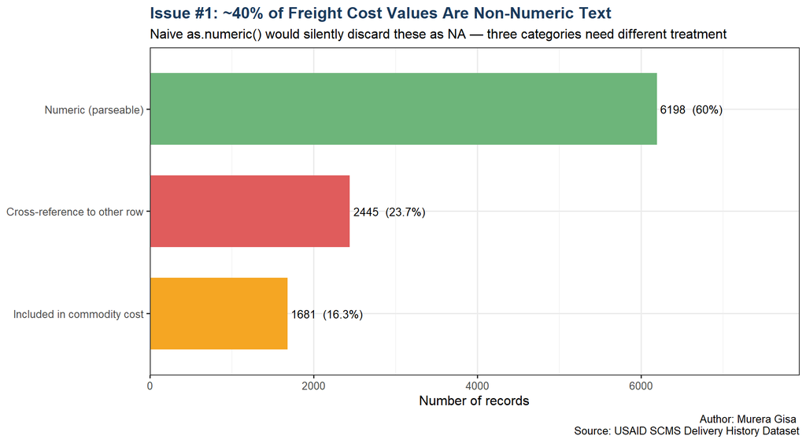

```r
non_numeric_n <- sum(freight_classes$n[freight_classes$category != "Numeric (parseable)"])

#Visualization

p1 <- ggplot(freight_classes,
             aes(x = reorder(category, n), y = n, fill = category)) +
  geom_col(width = 0.7, show.legend = FALSE) +
  geom_text(aes(label = paste0(n, "  (", pct, "%)")),
            hjust = -0.05, size = 3.6) +
  coord_flip() +
  scale_fill_manual(values = c(
    "Numeric (parseable)"             = "#6DB57A",
    "Included in commodity cost"      = "#F5A623",
    "Cross-reference to other row"    = "#E05C5C",
    "Blank / missing"                 = "#B0B0B0",
    "Other text"                      = "#888888"
  )) +
  scale_y_continuous(expand = expansion(mult = c(0, 0.28))) +
  labs(
    title    = "Issue #1: ~40% of Freight Cost Values Are Non-Numeric Text",
    subtitle = "Naive as.numeric() would silently discard these as NA — three categories need different treatment",
    x = NULL, y = "Number of records",
    caption  = "Author: Murera Gisa \n Source: USAID SCMS Delivery History Dataset"
  ) +
  theme_bw(base_size = 12) +
  theme(plot.title = element_text(face = "bold", colour = "#1A3A5C"))

print(p1)
```

```r
ggsave("reports/figures/issue1_non_numeric_freight.png", p1, width = 10, height = 4.5, dpi = 150)
non_numeric_n <- sum(freight_classes$n[freight_classes$category != "Numeric (parseable)"])
```

**Business Impact:** Ignoring this issue would result in $40\%$ data loss for any freight cost analysis, potentially biasing results toward shipments that explicitly itemize freight costs.